# R Notebook

Kriti Shah, Enat Ayele, Kranti Rumalla, Angie Jang

4/25/2021

```r
library(tidyverse)
library(skimr)
library(tidymodels)
library(janitor)
library(vcd)
library(corrplot)
library(corrr)

patients_data <- read_csv("data/unprocessed/train_data.csv") %>%
  clean_names()
```

## Initial overview of data

Our data was taken from a Kaggle dataset called [AV: Healthcare Analytics II](https://www.kaggle.com/nehaprabhavalkar/av-healthcare-analytics-ii) published by Neha Prabhavlakar in 2020. The data was compiled by Analytics Vidhya for a Kaggle competition exploring the theme of healthcare analytics and the application of machine learning on healthcare case studies.

In general, the dataset contains information on various factors that may influence the length of stay for a patient during the COVID-19 pandemic. Ultimately, using these variables, we were intending to train models to predict the length of stay by relating to the response variable (`stay` – number of stay days by the patient) with the following 13 predictor variables:

`hospital_code`: unique code for hospital

`hospital_type_code`: unique code for type of hospital

`hospital_region_code`: region code of hospital

`available_extra_rooms_in_hospital`: number of extra rooms available in the hospital

`department`: department overlooking the case

`ward_type`: code for the ward type

`ward_facility_code`: code for the ward facility

`bed_grade`: condition of bed in the ward

`visitors_with_patient`: number of visitors with patient

`age`: age of the patient

`severity_of_illness`: severity of illness recorded at the time of admission

`type_of_admission`: admission type registered by the hospital

`admission_deposit`: deposit at the admission time

```r
skim_without_charts(patients_data)
```

Data summary

| Name | patients_data |
| --- | --- |
| Number of rows | 318438 |
| Number of columns | 18 |
| _______________________ |  |
| Column type frequency: |  |
| character | 9 |
| numeric | 9 |
| ________________________ |  |
| Group variables | None |

**Variable type: character**

| skim_variable | n_missing | complete_rate | min | max | empty | n_unique | whitespace |
| --- | --- | --- | --- | --- | --- | --- | --- |
| hospital_type_code | 0 | 1 | 1 | 1 | 0 | 7 | 0 |
| hospital_region_code | 0 | 1 | 1 | 1 | 0 | 3 | 0 |
| department | 0 | 1 | 7 | 18 | 0 | 5 | 0 |
| ward_type | 0 | 1 | 1 | 1 | 0 | 6 | 0 |
| ward_facility_code | 0 | 1 | 1 | 1 | 0 | 6 | 0 |
| type_of_admission | 0 | 1 | 6 | 9 | 0 | 3 | 0 |
| severity_of_illness | 0 | 1 | 5 | 8 | 0 | 3 | 0 |
| age | 0 | 1 | 4 | 6 | 0 | 10 | 0 |
| stay | 0 | 1 | 4 | 18 | 0 | 11 | 0 |

**Variable type: numeric**

| skim_variable | n_missing | complete_rate | mean | sd | p0 | p25 | p50 | p75 | p100 |
| --- | --- | --- | --- | --- | --- | --- | --- | --- | --- |
| case_id | 0 | 1.00 | 159219.50 | 91925.28 | 1 | 79610.25 | 159219.5 | 238828.8 | 318438 |
| hospital_code | 0 | 1.00 | 18.32 | 8.63 | 1 | 11.00 | 19.0 | 26.0 | 32 |
| city_code_hospital | 0 | 1.00 | 4.77 | 3.10 | 1 | 2.00 | 5.0 | 7.0 | 13 |
| available_extra_rooms_in_hospital | 0 | 1.00 | 3.20 | 1.17 | 0 | 2.00 | 3.0 | 4.0 | 24 |
| bed_grade | 113 | 1.00 | 2.63 | 0.87 | 1 | 2.00 | 3.0 | 3.0 | 4 |
| patientid | 0 | 1.00 | 65747.58 | 37979.94 | 1 | 32847.00 | 65724.5 | 98470.0 | 131624 |
| city_code_patient | 4532 | 0.99 | 7.25 | 4.75 | 1 | 4.00 | 8.0 | 8.0 | 38 |
| visitors_with_patient | 0 | 1.00 | 3.28 | 1.76 | 0 | 2.00 | 3.0 | 4.0 | 32 |
| admission_deposit | 0 | 1.00 | 4880.75 | 1086.78 | 1800 | 4186.00 | 4741.0 | 5409.0 | 11008 |

Lastly, for our models, we also decided to exclude `case_id` and `patientid` because these were unique identifiers for each patient that would not show important relationships in the data.

## Essential Findings (Important or Interesting)

### Investigation of Response Variable

Our response variable is skewed right.

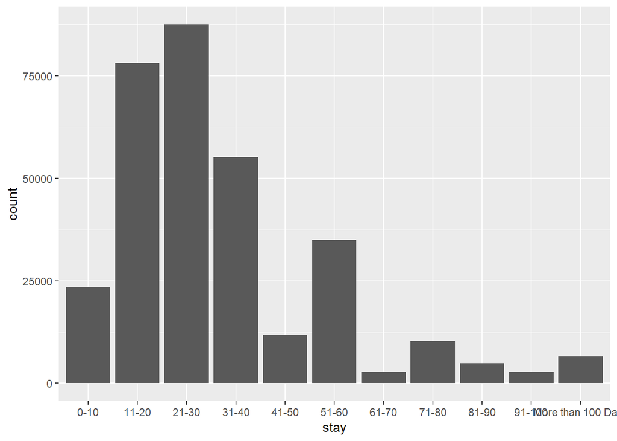

```r
ggplot(patients_data) +
  geom_bar(mapping = aes(stay))
```

### Investigation of Important Predictor Variables

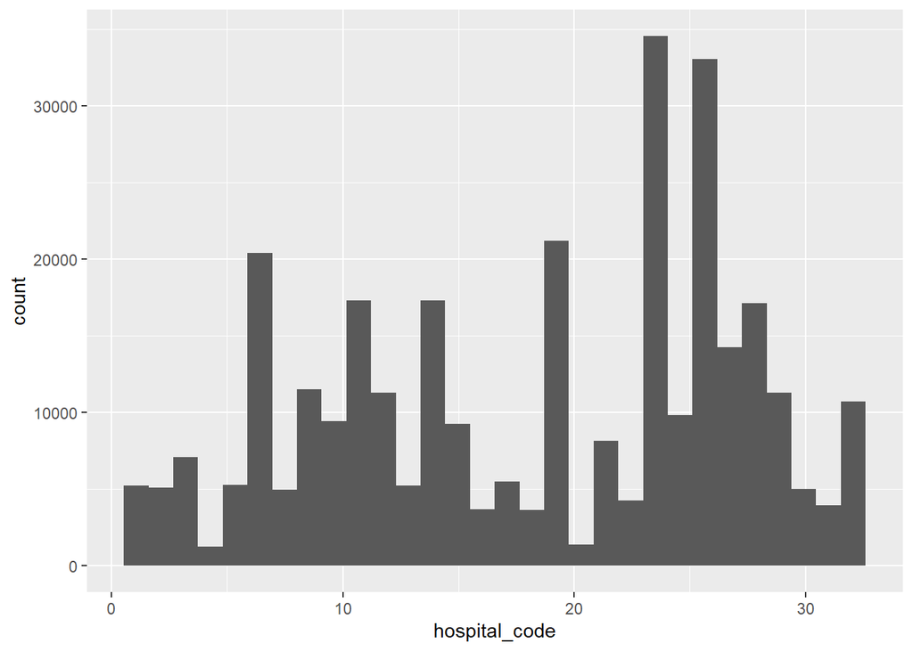

```r
ggplot(patients_data) +
  geom_histogram(mapping = aes(hospital_code))
```

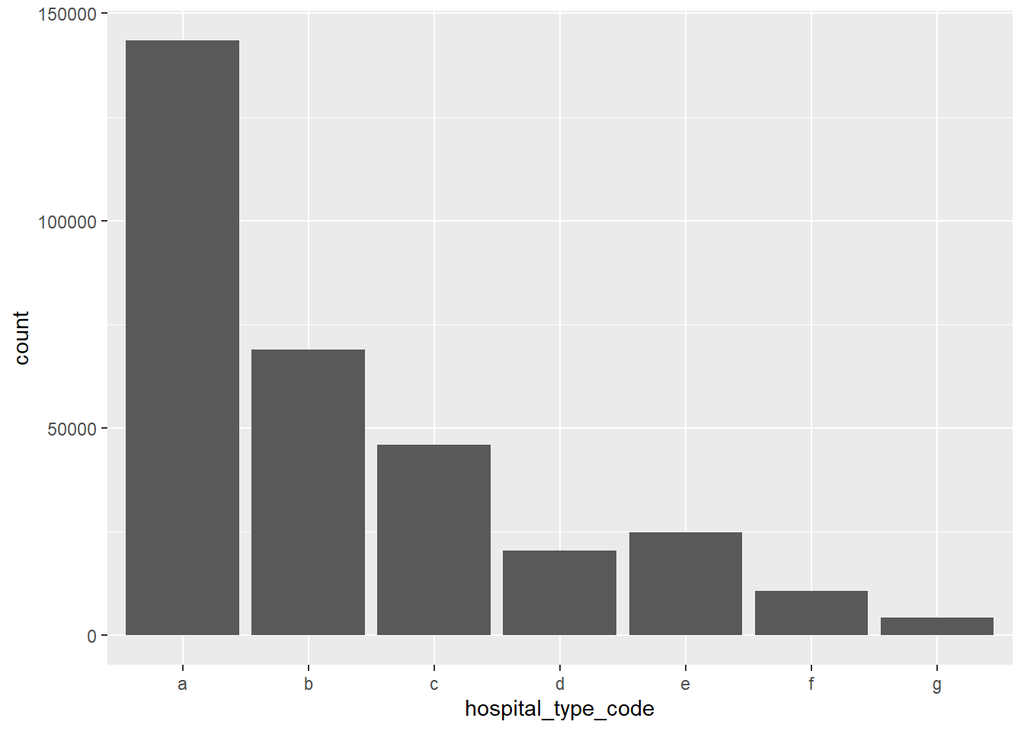

```r
ggplot(patients_data) +
  geom_bar(mapping = aes(hospital_type_code))
```

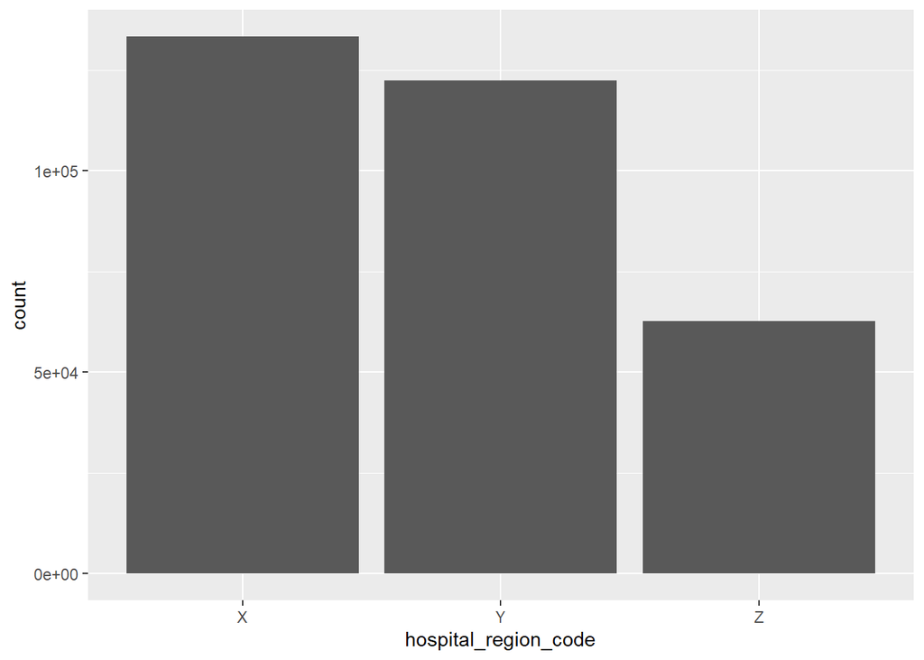

```r
ggplot(patients_data) +
  geom_bar(mapping = aes(hospital_region_code))
```

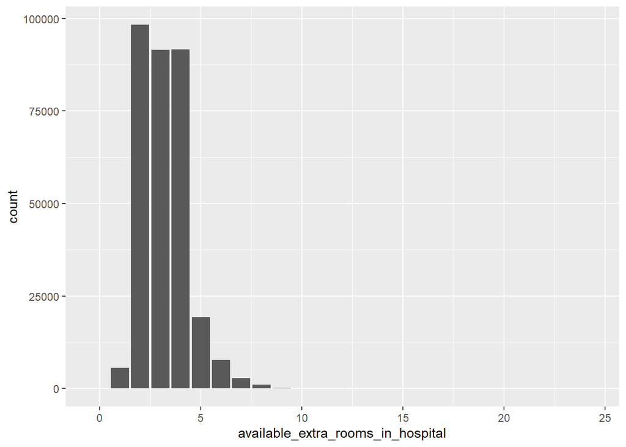

```r
ggplot(patients_data) +
  geom_bar(mapping = aes(available_extra_rooms_in_hospital))
```

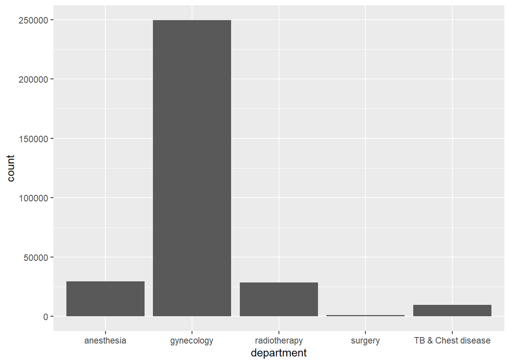

```r
ggplot(patients_data) +
  geom_bar(mapping = aes(department))
```

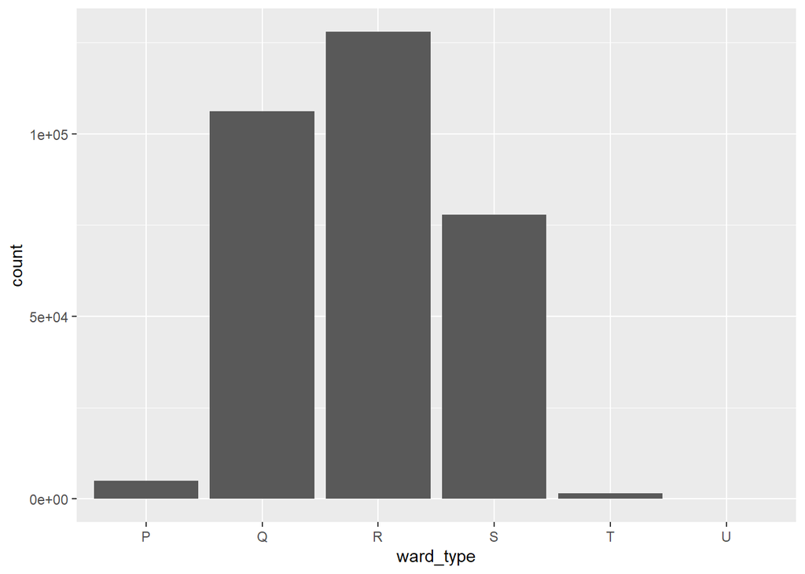

```r
ggplot(patients_data) +
  geom_bar(mapping = aes(ward_type))
```

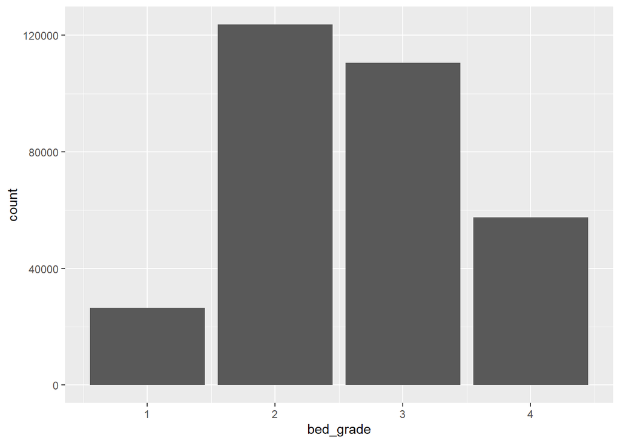

```r
ggplot(patients_data) +
  geom_bar(mapping = aes(bed_grade))
```

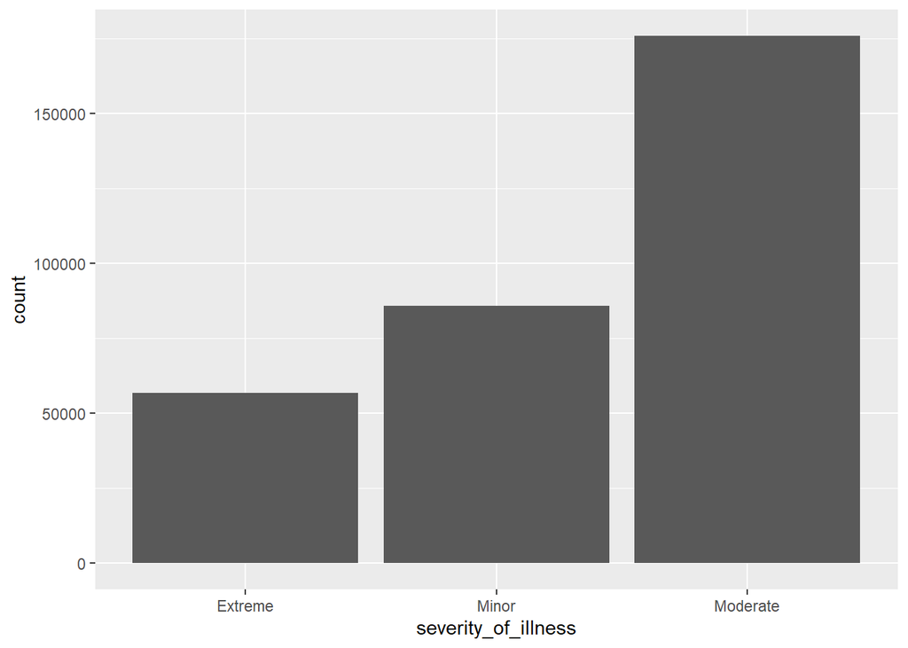

```r
ggplot(patients_data) +
  geom_bar(mapping = aes(severity_of_illness))
```

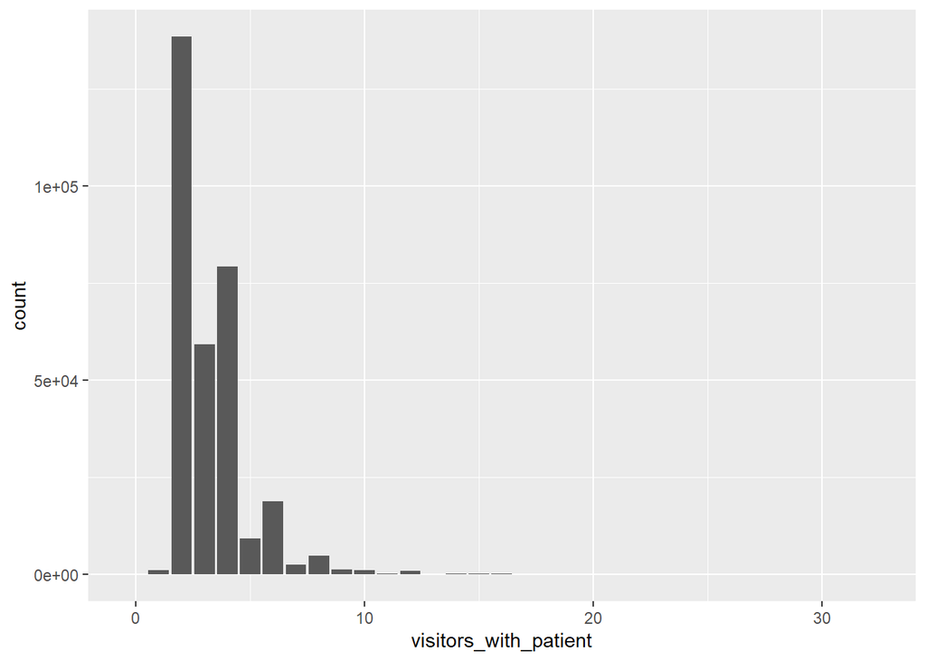

```r
ggplot(patients_data) +
  geom_bar(mapping = aes(visitors_with_patient))
```

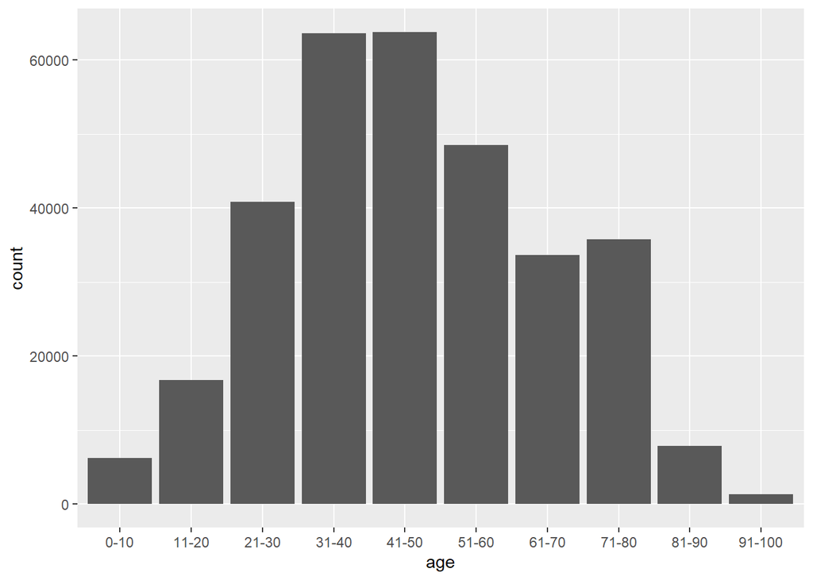

```r
ggplot(patients_data) +
  geom_bar(mapping = aes(age))
```

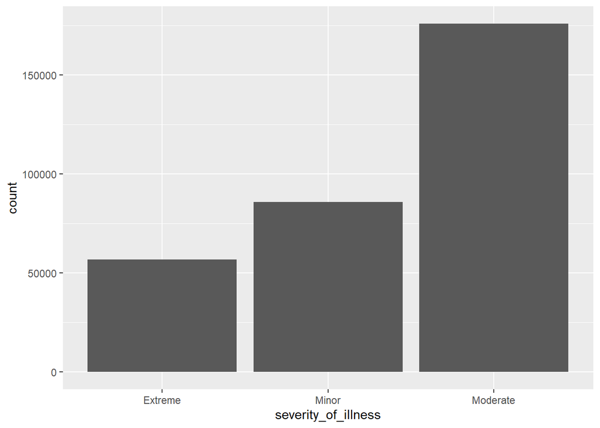

```r
ggplot(patients_data) +
  geom_bar(mapping = aes(severity_of_illness))
```

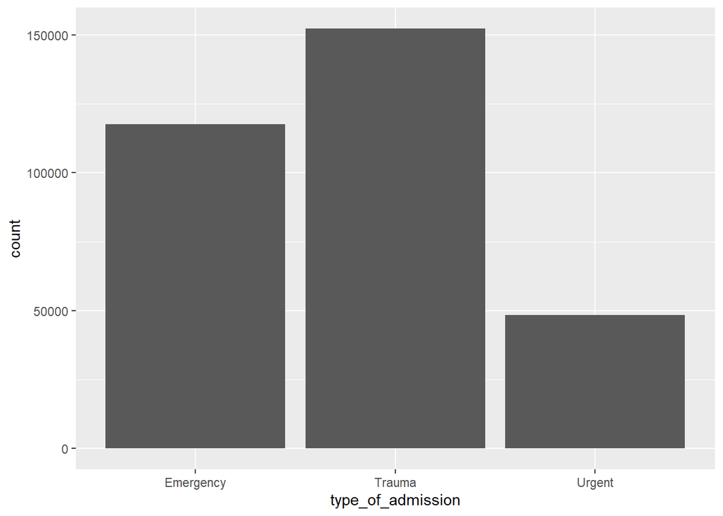

```r
ggplot(patients_data) +
  geom_bar(mapping = aes(type_of_admission))
```

### Interesting Relationships Between Predictor and Response Variables

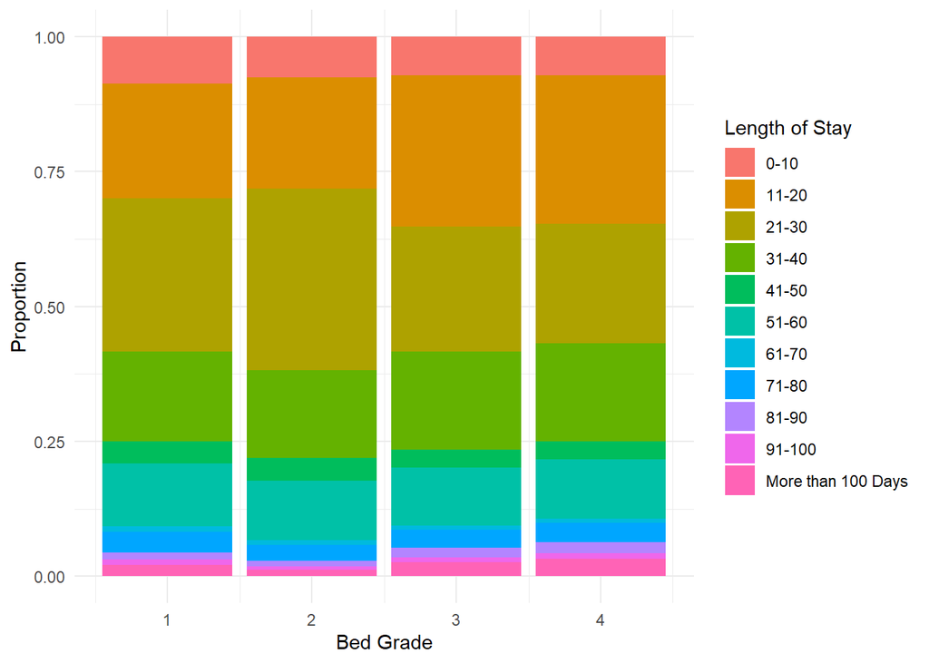

```r
ggplot(patients_data, aes(x = bed_grade, fill = stay)) +
  geom_bar(position = "fill") +
  theme_minimal() +
  labs(
    fill = "Length of Stay",
    x = "Bed Grade",
    y = "Proportion"
  )
```

There is a direct relationship between age and length of stay. As age increases, so does the length of stay.

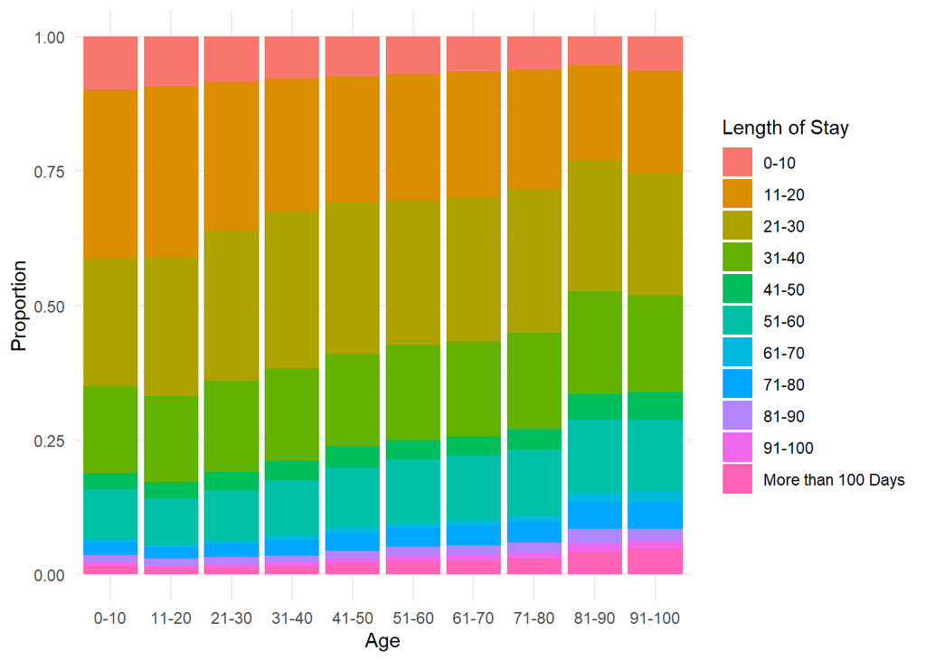

```r
ggplot(patients_data, aes(x = age, fill = stay)) +
  geom_bar(position = "fill") +
  theme_minimal() +
  labs(
    fill = "Length of Stay",
    x = "Age",
    y = "Proportion"
  )
```

Among the different departments, surgery had the longest length of stay.

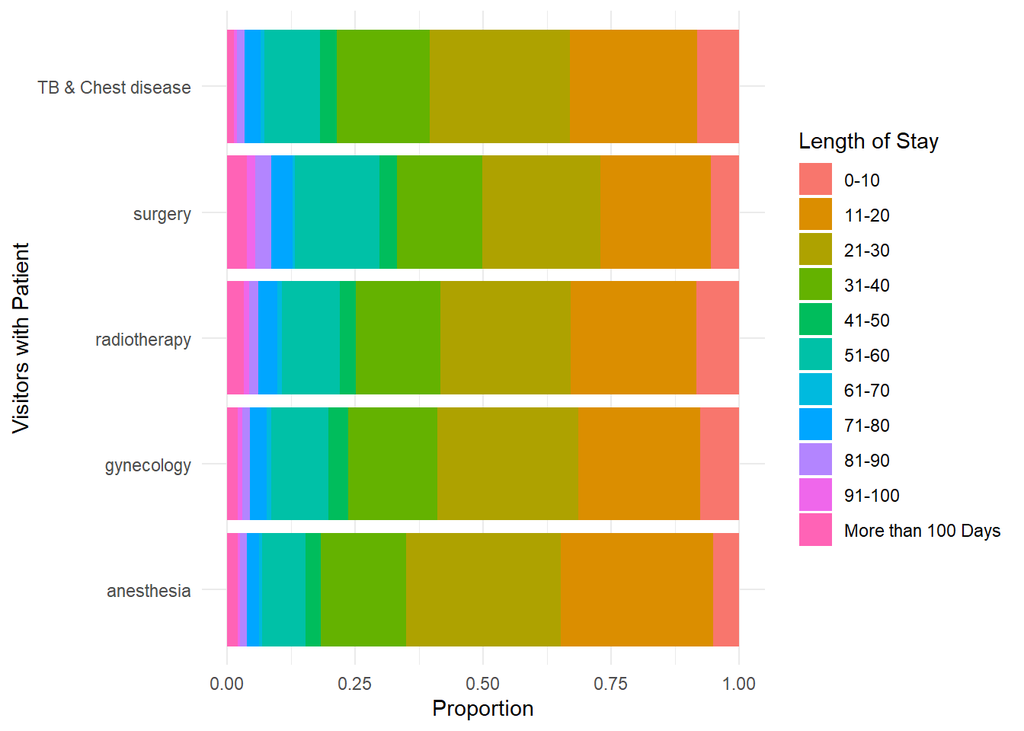

```r
ggplot(patients_data, aes(x = department, fill = stay)) +
  geom_bar(position = "fill") +
  theme_minimal() +
  labs(
    fill = "Length of Stay",
    x = "Visitors with Patient",
    y = "Proportion"
  ) +
  coord_flip()
```

Compared to other admission types, trauma patients have the longest length of stay.

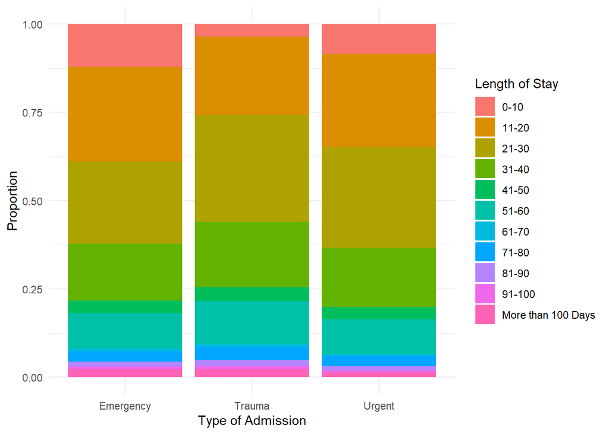

```r
ggplot(patients_data, aes(x = type_of_admission, fill = stay)) +
  geom_bar(position = "fill") +
  theme_minimal() +
  labs(
    fill = "Length of Stay",
    x = "Type of Admission",
    y = "Proportion"
  )
```

Patients how had severity of illness that were extreme had the longest length of stay.

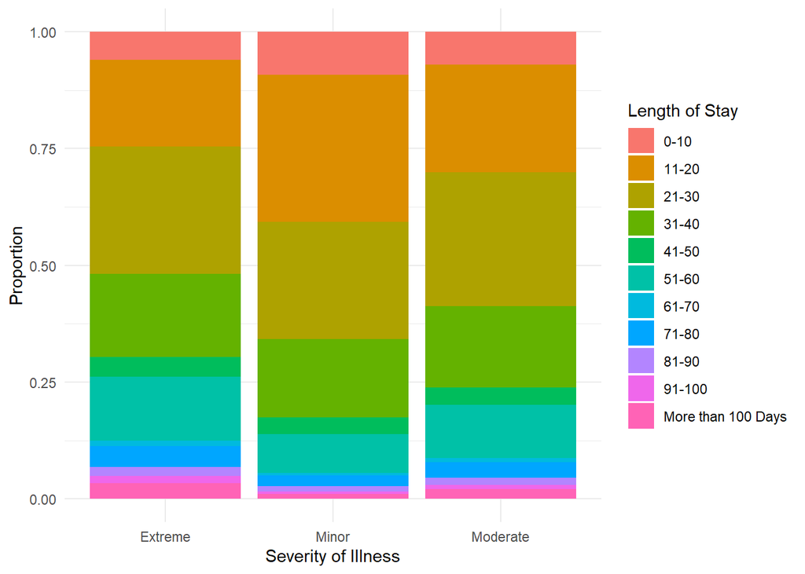

```r
# Extreme illness has longest stay
ggplot(patients_data, aes(x = severity_of_illness, fill = stay)) +
  geom_bar(position = "fill") +
  theme_minimal() +
  labs(
    fill = "Length of Stay",
    x = "Severity of Illness",
    y = "Proportion"
  )
```

There is also a direct relationship between length of stay and the number of vistors. As the length of stay increases, so does the number of visitors.

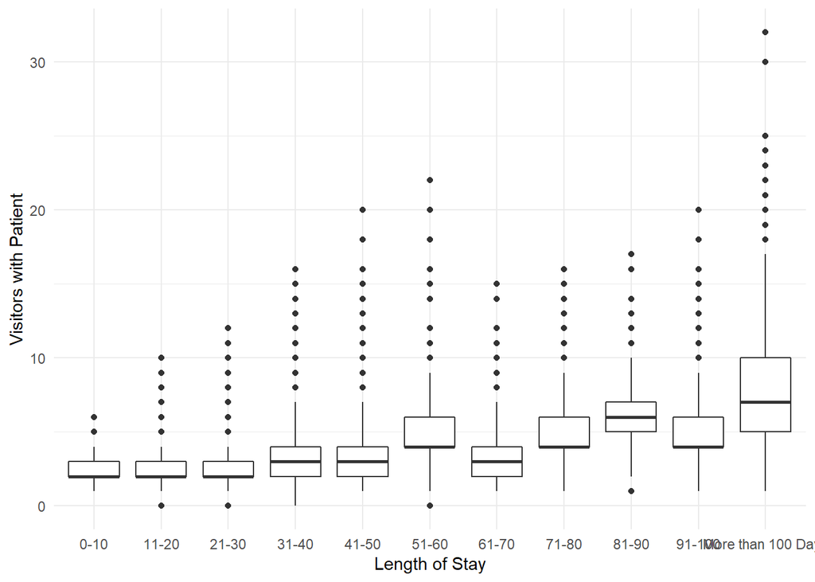

```r
ggplot(patients_data, mapping = aes(x = stay, y = visitors_with_patient)) +
  geom_boxplot() +
  theme_minimal() +
  labs(
    x = "Length of Stay",
    y = "Visitors with Patient"
  )
```

### Interesting relationships Among Predictor Variables

As the number of visitors per patient increases, the available extra rooms in the hospital decreases.

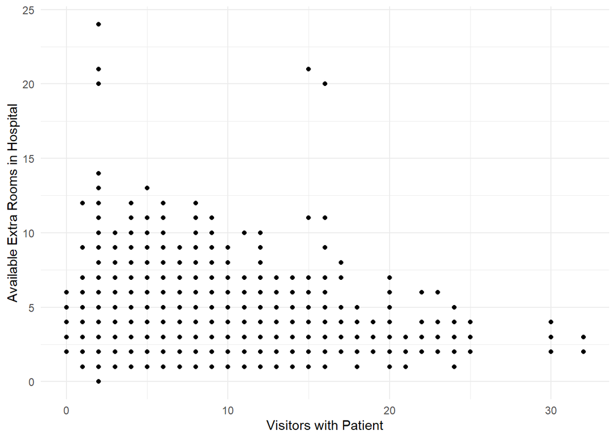

```r
ggplot(patients_data, mapping = aes(visitors_with_patient, available_extra_rooms_in_hospital)) +
  geom_point() +
  labs(
    x = "Visitors with Patient",
    y = "Available Extra Rooms in Hospital"
  ) +
  theme_minimal()
```

Our findings are important because they allow us to focus on predictors that have an impact on the response variable with which we can build models. From our exploration, we are able to see that our response variable is skewed to the right which means that it would have to be stratified in our split. Some of the predictors also look unevenly distributed and we will have to normalize/log transform prior to creating our model. We also determined that the interaction terms for this dataset could be visitors per patient and available extra rooms in hospital. This will be important for when we create the recipe for our models.

## Secondary Findings

We viewed two variables in the data as either being unimportant or showing some potential: hospital_region_code and ward_type. Based on the first graph seen below, it is important to note that there is no significant difference in length of stay between regions. We didn’t find this surprising since we didn’t know what each hospital region represented (it is not mentioned in the codebook).

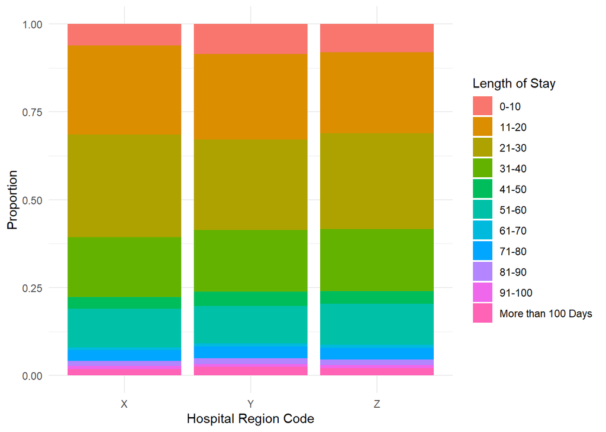

```r
ggplot(patients_data, aes(x = hospital_region_code, fill = stay)) +
  geom_bar(position = "fill") +
  labs(
    x = "Hospital Region Code",
    y = "Proportion",
    fill = "Length of Stay"
  ) +
  theme_minimal()
```

We thought ward type showed some potential since there was clear indication that different wards had different lengths of stay. But, once again, because the codebook did not explain what each ward type was, we thought this finding was not as important as the other variables we looked at.

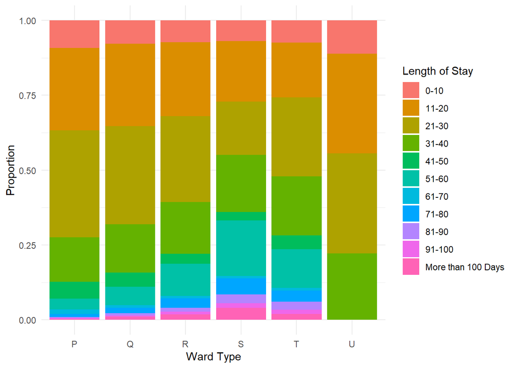

```r
ggplot(patients_data, aes(x = ward_type, fill = stay)) +
  geom_bar(position = "fill") +
  labs(
    x = "Ward Type",
    y = "Proportion",
    fill = "Length of Stay"
  ) +
  theme_minimal()
```